# Tratamiento de valores perdidos con conjunto de datos Titanic

Juan Gómez Romero

Tratamiento de valores perdidos con el dataset [titanic](https://www.kaggle.com/c/titanic/).

**En este cuaderno ampliaremos el código desarrollado en titanic.Rmd para tratar los valores perdidos de formas más sofisticadas.**

Internamente, [`rpart`](https://cran.r-project.org/web/packages/rpart/vignettes/longintro.pdf) puede utilizar un procedimiento para estimar los valores perdidos. Otras técnicas se limitan a omitir las filas con valores perdidos, lo que significa perder muchos datos significativos. Es conveniente por tanto gestionar los valores perdidos de una forma más controlada.

# Preprocesamiento de datos

Comenzamos leyendo el fichero de datos:

```r
data_raw <- read_csv('train.csv')
data_raw
```

| PassengerId | Survived | Pclass | Name | Sex | Age | SibSp | Parch | Ticket | Fare | Cabin | Embarked |
| --- | --- | --- | --- | --- | --- | --- | --- | --- | --- | --- | --- |
| 1 | 0 | 3 | Braund, Mr. Owen Harris | male | 22.00 | 1 | 0 | A/5 21171 | 7.2500 | NA | S |
| 2 | 1 | 1 | Cumings, Mrs. John Bradley (Florence Briggs Thayer) | female | 38.00 | 1 | 0 | PC 17599 | 71.2833 | C85 | C |
| 3 | 1 | 3 | Heikkinen, Miss. Laina | female | 26.00 | 0 | 0 | STON/O2. 3101282 | 7.9250 | NA | S |
| 4 | 1 | 1 | Futrelle, Mrs. Jacques Heath (Lily May Peel) | female | 35.00 | 1 | 0 | 113803 | 53.1000 | C123 | S |
| 5 | 0 | 3 | Allen, Mr. William Henry | male | 35.00 | 0 | 0 | 373450 | 8.0500 | NA | S |
| 6 | 0 | 3 | Moran, Mr. James | male | NA | 0 | 0 | 330877 | 8.4583 | NA | Q |
| 7 | 0 | 1 | McCarthy, Mr. Timothy J | male | 54.00 | 0 | 0 | 17463 | 51.8625 | E46 | S |
| 8 | 0 | 3 | Palsson, Master. Gosta Leonard | male | 2.00 | 3 | 1 | 349909 | 21.0750 | NA | S |
| 9 | 1 | 3 | Johnson, Mrs. Oscar W (Elisabeth Vilhelmina Berg) | female | 27.00 | 0 | 2 | 347742 | 11.1333 | NA | S |
| 10 | 1 | 2 | Nasser, Mrs. Nicholas (Adele Achem) | female | 14.00 | 1 | 0 | 237736 | 30.0708 | NA | C |

[output cut: 881 more lines]

# MissingDataGUI

MissingDataGUI es una herramienta para explorar y reparar valores perdidos. Si bien su interfaz gráfica puede facilitar la gestión, la falta de documentación la hacen difícil de utilizar. Además, la biblioteca no ha sido actualizada y ya no se encuentra en CRAN.

```r
# library(MissingDataGUI)
# if (interactive()) {
#        MissingDataGUI()
# }
```

# VIM

[VIM](https://cran.r-project.org/web/packages/VIM/index.html) facilita la visualización de la distribución de los valores perdidos. Puede utilizarse en combinación con [`funModeling`](https://livebook.datascienceheroes.com/exploratory-data-analysis.html#dataset-health-status).

```r
library(VIM)
```

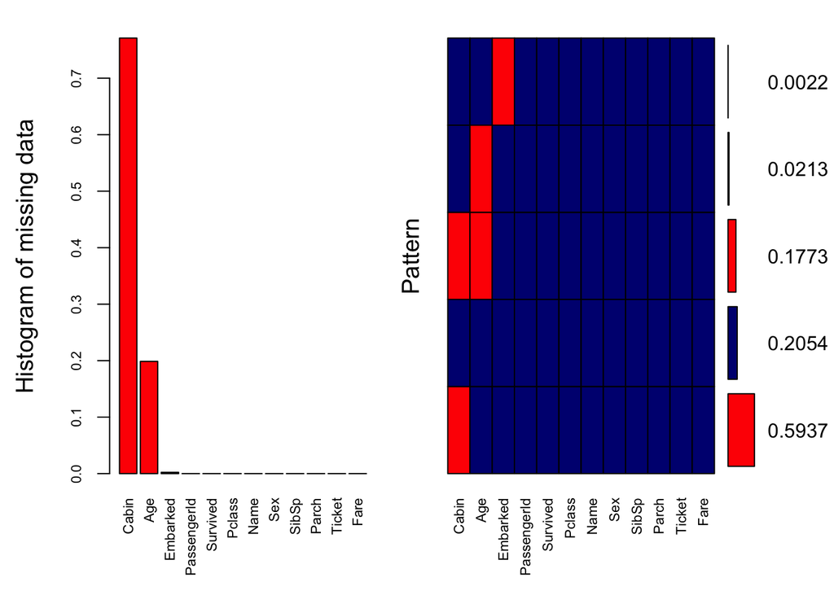

```
##
##  Variables sorted by number of missings:
##     Variable       Count
##        Cabin 0.771043771
##          Age 0.198653199
##     Embarked 0.002244669
##  PassengerId 0.000000000
##     Survived 0.000000000
##       Pclass 0.000000000
##         Name 0.000000000
##          Sex 0.000000000
##        SibSp 0.000000000
##        Parch 0.000000000
##       Ticket 0.000000000
##         Fare 0.000000000
```

```r
aggr(data_raw, col=c('navyblue','red'), numbers=TRUE, sortVars=TRUE, labels=names(data_raw), cex.axis=.7, gap=3, ylab=c("Histogram of missing data", "Pattern"))
```

# finalfit

Recientemente, [finalfit](https://finalfit.org) se está consolidando como paquete para preprocesamiento y visualización, con utilidades para las tareas de revisión de valores perdidos.

```r
library(finalfit)
ff_glimpse(data_raw)
```

```
## $Continuous
##                   label var_type   n missing_n missing_percent  mean    sd min
## PassengerId PassengerId    <dbl> 891         0             0.0 446.0 257.4 1.0
## Survived       Survived    <dbl> 891         0             0.0   0.4   0.5 0.0
## Pclass           Pclass    <dbl> 891         0             0.0   2.3   0.8 1.0
## Age                 Age    <dbl> 714       177            19.9  29.7  14.5 0.4
## SibSp             SibSp    <dbl> 891         0             0.0   0.5   1.1 0.0
## Parch             Parch    <dbl> 891         0             0.0   0.4   0.8 0.0
## Fare               Fare    <dbl> 891         0             0.0  32.2  49.7 0.0
##             quartile_25 median quartile_75   max
## PassengerId       223.5  446.0       668.5 891.0
## Survived            0.0    0.0         1.0   1.0
## Pclass              2.0    3.0         3.0   3.0
## Age                20.1   28.0        38.0  80.0
## SibSp               0.0    0.0         1.0   8.0
## Parch               0.0    0.0         0.0   6.0
## Fare                7.9   14.5        31.0 512.3
##
## $Categorical
##             label var_type   n missing_n missing_percent levels_n levels
## Name         Name    <chr> 891         0             0.0      891      -
## Sex           Sex    <chr> 891         0             0.0        2      -
## Ticket     Ticket    <chr> 891         0             0.0      681      -
## Cabin       Cabin    <chr> 204       687            77.1      147      -
## Embarked Embarked    <chr> 889         2             0.2        3      -
##          levels_count levels_percent
## Name                -              -
## Sex                 -              -
## Ticket              -              -
## Cabin               -              -
## Embarked            -              -
```

[finalfit](https://finalfit.org) permite estudiar la distribución de valores perdidos en las variables, tanto con tablas como gráficamente.

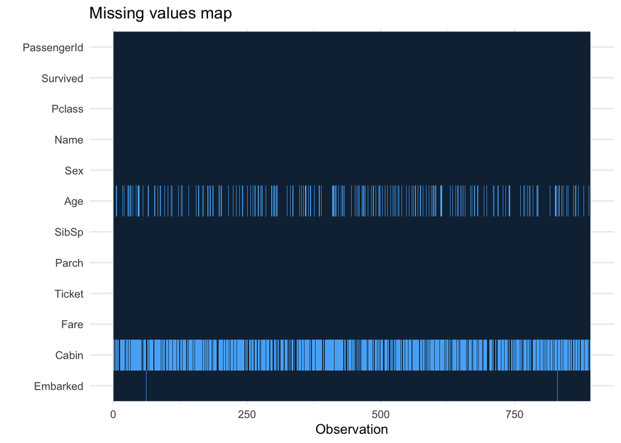

```r
data_raw %>%
  missing_plot()
```

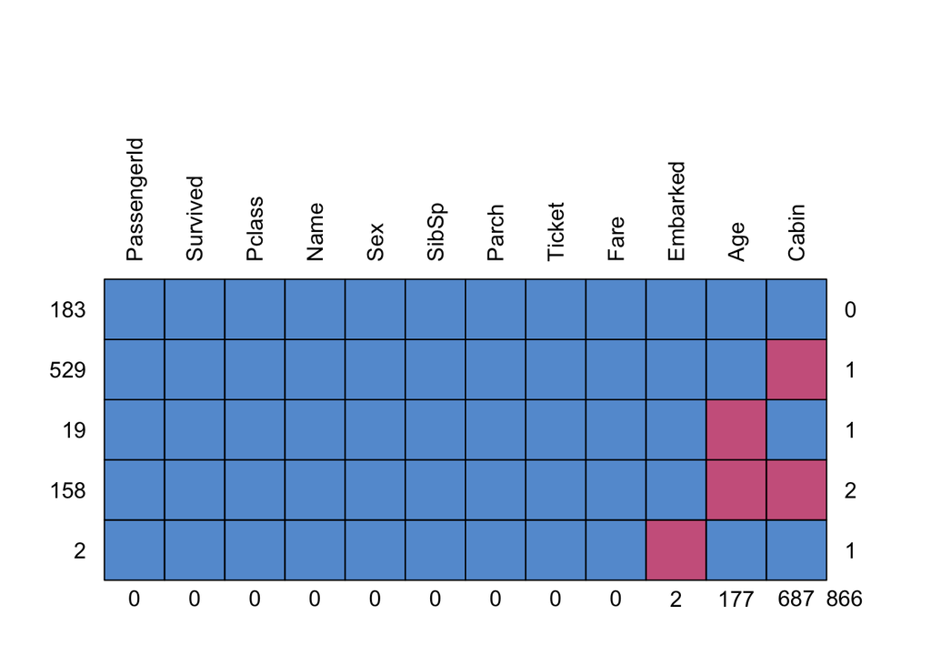

```
##     PassengerId Survived Pclass Name Sex SibSp Parch Ticket Fare Embarked Age
## 183           1        1      1    1   1     1     1      1    1        1   1
## 529           1        1      1    1   1     1     1      1    1        1   1
## 19            1        1      1    1   1     1     1      1    1        1   0
## 158           1        1      1    1   1     1     1      1    1        1   0
## 2             1        1      1    1   1     1     1      1    1        0   1
##               0        0      0    0   0     0     0      0    0        2 177
##     Cabin
## 183     1   0
## 529     0   1
## 19      1   1
## 158     0   2
## 2       1   1
##       687 866
```

```r
data_raw %>%
  missing_pattern()
```

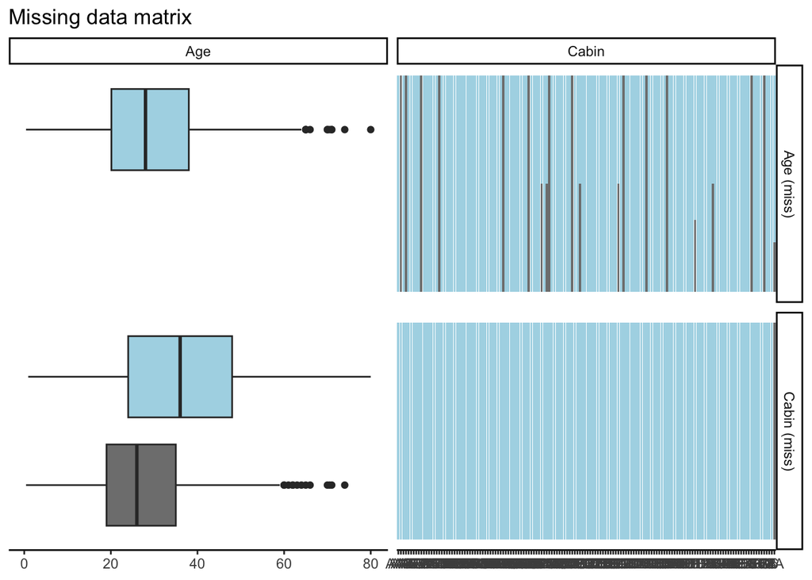

```r
data_raw %>%
  missing_pairs("Age", "Cabin", position = "fill")
```

```r
data_raw %>%
  missing_compare("Age", "Cabin")
```

| Missing data analysis: Age |  | Not missing | Missing | p |
| --- | --- | --- | --- | --- |
| Cabin | A10 | 1 (100.0) |  | 0.118 |
|  | A16 | 1 (100.0) |  |  |
|  | A20 | 1 (100.0) |  |  |
|  | A23 | 1 (100.0) |  |  |
|  | A24 | 1 (100.0) |  |  |
|  | A26 | 1 (100.0) |  |  |
|  | A31 | 1 (100.0) |  |  |
|  | A34 | 1 (100.0) |  |  |
|  | A36 | 1 (100.0) |  |  |
|  | A5 | 1 (100.0) |  |  |

[output cut: 137 more lines]

# MICE

[MICE](https://stefvanbuuren.name/mice/) es una de las bibliotecas más completas para realizar imputación de valores perdidos.

En el conjunto de datos existen valores perdidos en: ‘Cabin’, ‘Age’, ‘Embarked’. Con [MICE](https://stefvanbuuren.name/mice/) podemos crear un modelo de imputación que emplee [diferentes técnicas de imputación](https://www.rdocumentation.org/packages/mice/versions/3.7.0/topics/mice) para cada columna. Con [`complete`](https://www.rdocumentation.org/packages/mice/versions/3.7.0/topics/complete) obtenemos el resultado de la imputación de acuerdo al modelo generado.

```r
imputation <- mice(data_raw, method = c("", "", "", "", "", "mean", "", "", "", "", "cart", "cart"))
imputation
```

```
## Class: mids
## Number of multiple imputations:  5
## Imputation methods:
## PassengerId    Survived      Pclass        Name         Sex         Age
##          ""          ""          ""          ""          ""      "mean"
##       SibSp       Parch      Ticket        Fare       Cabin    Embarked
##          ""          ""          ""          ""          ""          ""
## PredictorMatrix:
##             PassengerId Survived Pclass Name Sex Age SibSp Parch Ticket Fare
## PassengerId           0        1      1    0   0   1     1     1      0    1
## Survived              1        0      1    0   0   1     1     1      0    1
## Pclass                1        1      0    0   0   1     1     1      0    1
## Name                  1        1      1    0   0   1     1     1      0    1
## Sex                   1        1      1    0   0   1     1     1      0    1
## Age                   1        1      1    0   0   0     1     1      0    1
##             Cabin Embarked
## PassengerId     0        0
## Survived        0        0
## Pclass          0        0
## Name            0        0
## Sex             0        0
## Age             0        0
## Number of logged events:  5
##   it im dep     meth      out
## 1  0  0     constant     Name
## 2  0  0     constant      Sex
## 3  0  0     constant   Ticket
## 4  0  0     constant    Cabin
## 5  0  0     constant Embarked
```

```r
head(complete(imputation))
```

|  | PassengerId | Survived | Pclass | Name | Sex | Age | SibSp | Parch | Ticket | Fare | Cabin | Embarked |
| --- | --- | --- | --- | --- | --- | --- | --- | --- | --- | --- | --- | --- |
| 1 | 1 | 0 | 3 | Braund, Mr. Owen Harris | male | 22.00000 | 1 | 0 | A/5 21171 | 7.2500 | NA | S |
| 2 | 2 | 1 | 1 | Cumings, Mrs. John Bradley (Florence Briggs Thayer) | female | 38.00000 | 1 | 0 | PC 17599 | 71.2833 | C85 | C |
| 3 | 3 | 1 | 3 | Heikkinen, Miss. Laina | female | 26.00000 | 0 | 0 | STON/O2. 3101282 | 7.9250 | NA | S |
| 4 | 4 | 1 | 1 | Futrelle, Mrs. Jacques Heath (Lily May Peel) | female | 35.00000 | 1 | 0 | 113803 | 53.1000 | C123 | S |
| 5 | 5 | 0 | 3 | Allen, Mr. William Henry | male | 35.00000 | 0 | 0 | 373450 | 8.0500 | NA | S |
| 6 | 6 | 0 | 3 | Moran, Mr. James | male | 29.69912 | 0 | 0 | 330877 | 8.4583 | NA | Q |

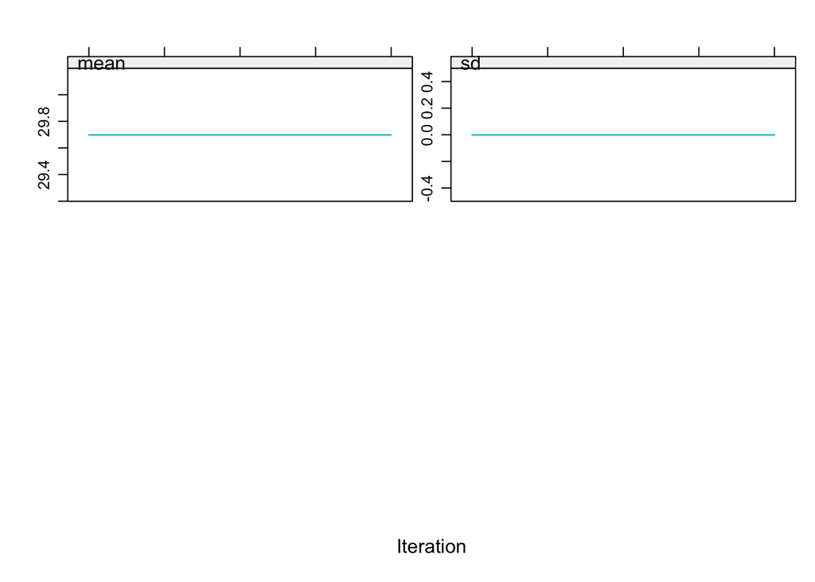

```r
plot(imputation)
```

[figure not shown]

```r
stripplot(imputation, pch = 20, cex = 1.2)
```

Podemos combinar `mice` y [`caret`](http://topepo.github.io/caret/) para crear manualmente modelos de predicción con varias imputaciones:

```r
library(caret)
# Particiones de datos y parametros generales
trainIndex <- createDataPartition(data_raw$Survived, p = .8, list = FALSE, times = 1)
rpartCtrl <- trainControl(verboseIter = F, classProbs = TRUE, summaryFunction = twoClassSummary)
rpartParametersGrid <- expand.grid(.cp = c(0.01, 0.05))

# Imputación resultado
data_raw_imputation_1 <-
  complete(imputation) %>%
  mutate(Survived = as.factor(ifelse(Survived == 1, 'Yes', 'No'))) %>%
  mutate(Pclass = as.factor(Pclass)) %>%
  mutate(Fare_Interval = as.factor(
    case_when(
      Fare >= 30 ~ 'More.than.30',
      Fare >= 20 & Fare < 30 ~ 'Between.20.30',
      Fare < 20 & Fare >= 10 ~ 'Between.10.20',
      Fare < 10 ~ 'Less.than.10'))) %>%
  select(Survived, Age, Pclass, Sex, Fare_Interval)

# Entrenar modelo 1
train   <- data_raw_imputation_1[ trainIndex, ]
val     <- data_raw_imputation_1[-trainIndex, ]
rPartModel_1 <- train(Survived ~ Age + Pclass + Sex + Fare_Interval, data = data_raw_imputation_1, method = "rpart", metric = "ROC", trControl = rpartCtrl, tuneGrid = rpartParametersGrid)

## Imputación alternativa
data_raw_imputation_2 <-
  complete(imputation, 2) %>%  # se selecciona la alternativa 2 de imputación
  mutate(Survived = as.factor(ifelse(Survived == 1, 'Yes', 'No'))) %>%
  mutate(Pclass = as.factor(Pclass)) %>%
  mutate(Fare_Interval = as.factor(
    case_when(
      Fare >= 30 ~ 'More.than.30',
      Fare >= 20 & Fare < 30 ~ 'Between.20.30',
      Fare < 20 & Fare >= 10 ~ 'Between.10.20',
      Fare < 10 ~ 'Less.than.10'))) %>%
  select(Survived, Age, Pclass, Sex, Fare_Interval)

# Entrenar modelo 2
train   <- data_raw_imputation_2[ trainIndex, ]
val     <- data_raw_imputation_2[-trainIndex, ]
rPartModel_2 <- train(Survived ~ Age + Pclass + Sex + Fare_Interval, data = data_raw_imputation_2, method = "rpart", metric = "ROC", trControl = rpartCtrl, tuneGrid = rpartParametersGrid)
```

Y después seleccionar el que mejor ha funcionado, en entrenamiento o validación. (En este caso no hay diferencias porque ambas imputaciones son idénticas.)

```r
# Comparación
prediction_1 <- predict(rPartModel_1, val, type = "raw")
(cm_train_1 <- confusionMatrix(prediction_1, val[["Survived"]]))
```

```
## Confusion Matrix and Statistics
##
##           Reference
## Prediction No Yes
##        No  88  21
##        Yes 12  57
##
##                Accuracy : 0.8146
##                  95% CI : (0.7496, 0.8688)
##     No Information Rate : 0.5618
##     P-Value [Acc > NIR] : 9.139e-13
##
##                   Kappa : 0.6186
##
##  Mcnemar's Test P-Value : 0.1637
##
##             Sensitivity : 0.8800
##             Specificity : 0.7308
##          Pos Pred Value : 0.8073
##          Neg Pred Value : 0.8261
##              Prevalence : 0.5618
##          Detection Rate : 0.4944
##    Detection Prevalence : 0.6124
##       Balanced Accuracy : 0.8054
##
##        'Positive' Class : No
##
```

```r
prediction_2 <- predict(rPartModel_2, val, type = "raw")
(cm_train_2 <- confusionMatrix(prediction_2, val[["Survived"]]))
```

```
## Confusion Matrix and Statistics
##
##           Reference
## Prediction No Yes
##        No  88  21
##        Yes 12  57
##
##                Accuracy : 0.8146
##                  95% CI : (0.7496, 0.8688)
##     No Information Rate : 0.5618
##     P-Value [Acc > NIR] : 9.139e-13
##
##                   Kappa : 0.6186
##
##  Mcnemar's Test P-Value : 0.1637
##
##             Sensitivity : 0.8800
##             Specificity : 0.7308
##          Pos Pred Value : 0.8073
##          Neg Pred Value : 0.8261
##              Prevalence : 0.5618
##          Detection Rate : 0.4944
##    Detection Prevalence : 0.6124
##       Balanced Accuracy : 0.8054
##
##        'Positive' Class : No
##
```

# NoiseFiltersR

Para gestionar valores con ruido, utilizamos las herramientas incluidas en [`NoiseFiltersR`](https://cran.r-project.org/web/packages/NoiseFiltersR/index.html).

```r
# install.packages(c("RWeka", "kknn", "rJava"))
# install.packages("NoiseFiltersR_0.1.0.tar.gz", repos = NULL, type = "source")
library(NoiseFiltersR)

data <- data_raw %>%
  mutate(Survived = as.factor(Survived)) %>%
  mutate(Pclass = as.factor(Pclass))   %>%
  mutate(Age = as.factor(Age))      %>%
  mutate(Sex = as.factor(Sex))      %>%
  select(Pclass, Survived, Age, Sex)

noise_filter <- AENN(Survived ~., data)
summary(noise_filter)
```

```
## Filter AENN applied to dataset data
##
## Call:
## AENN(formula = Survived ~ ., data = data)
##
## Parameters:
## k: 5
##
## Results:
## Number of removed instances: 294 (32.99663 %)
## Number of repaired instances: 0 (0 %)
```

```r
identical(noise_filter$cleanData, data[setdiff(1:nrow(data), noise_filter$remIdx), ])
```

```
## [1] TRUE
```